# Travel Package Purchase Prediction

## Problem Statement:

As a Data Scientist for a tourism company named "Visit with us". The Policy Maker of the company wants to enable and establish a viable business model to expand the customer base.

A viable business model is a central concept that helps you to understand the existing ways of doing the business and how to change the ways for the benefit of the tourism sector.

One of the ways to expand the customer base is to introduce a new offering of packages.

Currently, there are 5 types of packages the company is offering - Basic, Standard, Deluxe, Super Deluxe, King. Looking at the data of the last year, we observed that 18% of the customers purchased the packages.

However, the marketing cost was quite high because customers were contacted at random without looking at the available information.

The company is now planning to launch a new product i.e. Wellness Tourism Package. Wellness Tourism is defined as Travel that allows the traveler to maintain, enhance or kick-start a healthy lifestyle, and support or increase one's sense of well-being.

However, this time company wants to harness the available data of existing and potential customers to make the marketing expenditure more efficient.

As a Data Scientist at "Visit with us" travel company have to analyze the customers' data and information to provide recommendations to the Policy Maker and Marketing Team and also build a model to predict the potential customer who is going to purchase the newly introduced travel package.

## Objective:

To predict which customer is more likely to purchase the newly introduced travel package.

## Data Description:

#### Customer details:

- CustomerID: Unique customer ID
- ProdTaken: Whether the customer has purchased a package or not (0: No, 1: Yes)
- Age: Age of customer
- TypeofContact: How customer was contacted (Company Invited or Self Inquiry)
- CityTier: City tier depends on the development of a city, population, facilities, and living standards. The categories are ordered i.e. Tier 1 > Tier 2 > Tier 3
- Occupation: Occupation of customer
- Gender: Gender of customer
- NumberOfPersonVisiting: Total number of persons planning to take the trip with the customer
- PreferredPropertyStar: Preferred hotel property rating by customer
- MaritalStatus: Marital status of customer
- NumberOfTrips: Average number of trips in a year by customer
- Passport: The customer has a passport or not (0: No, 1: Yes)
- OwnCar: Whether the customers own a car or not (0: No, 1: Yes)
- NumberOfChildrenVisiting: Total number of children with age less than 5 planning to take the trip with the customer
- Designation: Designation of the customer in the current organization
- MonthlyIncome: Gross monthly income of the customer

#### Customer interaction data:

- PitchSatisfactionScore: Sales pitch satisfaction score
- ProductPitched: Product pitched by the salesperson
- NumberOfFollowups: Total number of follow-ups has been done by the salesperson after the sales pitch
- DurationOfPitch: Duration of the pitch by a salesperson to the customer

## Import necessary libraries

```python
# Library to suppress warnings or deprecation notes
import warnings
warnings.filterwarnings('ignore')

# Libraries to help with reading and manipulating data
import numpy as np
import pandas as pd

# Libraries to help with data visualization
import matplotlib.pyplot as plt
%matplotlib inline
import seaborn as sns

# Libraries to split data, impute missing values
from sklearn.model_selection import train_test_split
from sklearn.impute import SimpleImputer

# Libraries to import decision tree classifier and different ensemble classifiers
from sklearn.ensemble import BaggingClassifier
from sklearn.ensemble import RandomForestClassifier
from sklearn.ensemble import AdaBoostClassifier, GradientBoostingClassifier
from sklearn.ensemble import StackingClassifier
from sklearn.tree import DecisionTreeClassifier

# Libtune to tune model, get different metric scores
from sklearn import metrics
from sklearn.metrics import confusion_matrix, classification_report, accuracy_score, precision_score, recall_score, f1_score, roc_auc_score
from sklearn.model_selection import GridSearchCV
```

## Read the dataset¶

```python
tourism = pd.read_csv('Tourism-Table.csv')
```

```python
# copying data to another varaible to avoid any changes to original data
data = tourism.copy()
```

### View the first and last 5 rows of the dataset.

```python
data.head()
```

|  | CustomerID | ProdTaken | Age | TypeofContact | CityTier | DurationOfPitch | Occupation | Gender | NumberOfPersonVisiting | NumberOfFollowups | ProductPitched | PreferredPropertyStar | MaritalStatus | NumberOfTrips | Passport | PitchSatisfactionScore | OwnCar | NumberOfChildrenVisiting | Designation | MonthlyIncome |
| --- | --- | --- | --- | --- | --- | --- | --- | --- | --- | --- | --- | --- | --- | --- | --- | --- | --- | --- | --- | --- |
| 0 | 200000 | 1 | 41.0 | Self Enquiry | 3 | 6.0 | Salaried | Female | 3 | 3.0 | Deluxe | 3.0 | Single | 1.0 | 1 | 2 | 1 | 0.0 | Manager | 20993.0 |
| 1 | 200001 | 0 | 49.0 | Company Invited | 1 | 14.0 | Salaried | Male | 3 | 4.0 | Deluxe | 4.0 | Divorced | 2.0 | 0 | 3 | 1 | 2.0 | Manager | 20130.0 |
| 2 | 200002 | 1 | 37.0 | Self Enquiry | 1 | 8.0 | Free Lancer | Male | 3 | 4.0 | Basic | 3.0 | Single | 7.0 | 1 | 3 | 0 | 0.0 | Executive | 17090.0 |
| 3 | 200003 | 0 | 33.0 | Company Invited | 1 | 9.0 | Salaried | Female | 2 | 3.0 | Basic | 3.0 | Divorced | 2.0 | 1 | 5 | 1 | 1.0 | Executive | 17909.0 |
| 4 | 200004 | 0 | NaN | Self Enquiry | 1 | 8.0 | Small Business | Male | 2 | 3.0 | Basic | 4.0 | Divorced | 1.0 | 0 | 5 | 1 | 0.0 | Executive | 18468.0 |

```python
data.tail()
```

|  | CustomerID | ProdTaken | Age | TypeofContact | CityTier | DurationOfPitch | Occupation | Gender | NumberOfPersonVisiting | NumberOfFollowups | ProductPitched | PreferredPropertyStar | MaritalStatus | NumberOfTrips | Passport | PitchSatisfactionScore | OwnCar | NumberOfChildrenVisiting | Designation | MonthlyIncome |
| --- | --- | --- | --- | --- | --- | --- | --- | --- | --- | --- | --- | --- | --- | --- | --- | --- | --- | --- | --- | --- |
| 4883 | 204883 | 1 | 49.0 | Self Enquiry | 3 | 9.0 | Small Business | Male | 3 | 5.0 | Deluxe | 4.0 | Unmarried | 2.0 | 1 | 1 | 1 | 1.0 | Manager | 26576.0 |
| 4884 | 204884 | 1 | 28.0 | Company Invited | 1 | 31.0 | Salaried | Male | 4 | 5.0 | Basic | 3.0 | Single | 3.0 | 1 | 3 | 1 | 2.0 | Executive | 21212.0 |
| 4885 | 204885 | 1 | 52.0 | Self Enquiry | 3 | 17.0 | Salaried | Female | 4 | 4.0 | Standard | 4.0 | Married | 7.0 | 0 | 1 | 1 | 3.0 | Senior Manager | 31820.0 |
| 4886 | 204886 | 1 | 19.0 | Self Enquiry | 3 | 16.0 | Small Business | Male | 3 | 4.0 | Basic | 3.0 | Single | 3.0 | 0 | 5 | 0 | 2.0 | Executive | 20289.0 |
| 4887 | 204887 | 1 | 36.0 | Self Enquiry | 1 | 14.0 | Salaried | Male | 4 | 4.0 | Basic | 4.0 | Unmarried | 3.0 | 1 | 3 | 1 | 2.0 | Executive | 24041.0 |

### Understand the shape of the dataset.

```python
data.shape
```

```
(4888, 20)
```

- There are 4888 observations and 20 columns in the dataset

### Check the data types of the columns for the dataset.

```python
data.info()
```

```
<class 'pandas.core.frame.DataFrame'>
RangeIndex: 4888 entries, 0 to 4887
Data columns (total 20 columns):
 #   Column                    Non-Null Count  Dtype
---  ------                    --------------  -----
 0   CustomerID                4888 non-null   int64
 1   ProdTaken                 4888 non-null   int64
 2   Age                       4662 non-null   float64
 3   TypeofContact             4863 non-null   object
 4   CityTier                  4888 non-null   int64
 5   DurationOfPitch           4637 non-null   float64
 6   Occupation                4888 non-null   object
 7   Gender                    4888 non-null   object
 8   NumberOfPersonVisiting    4888 non-null   int64
 9   NumberOfFollowups         4843 non-null   float64
 10  ProductPitched            4888 non-null   object
 11  PreferredPropertyStar     4862 non-null   float64
 12  MaritalStatus             4888 non-null   object
 13  NumberOfTrips             4748 non-null   float64
 14  Passport                  4888 non-null   int64
 15  PitchSatisfactionScore    4888 non-null   int64
 16  OwnCar                    4888 non-null   int64
 17  NumberOfChildrenVisiting  4822 non-null   float64
 18  Designation               4888 non-null   object
 19  MonthlyIncome             4655 non-null   float64
dtypes: float64(7), int64(7), object(6)
memory usage: 763.9+ KB
```

- There are some missing values in few columns
- We have numeric and string columns

### Data Pre-Processing:

#### Fixing Datatypes

```python
data.drop(['CustomerID'],axis=1,inplace=True)
```

```python
#selecting all object datatypes and converting to category
category_cols = ['CityTier','ProdTaken','NumberOfPersonVisiting','NumberOfChildrenVisiting','PreferredPropertyStar','Passport','PitchSatisfactionScore','OwnCar']
data[category_cols] = data[category_cols].astype('category')

cols = data.select_dtypes(['object'])
for i in cols.columns:
    data[i] = data[i].astype('category')

data.info()
```

```
<class 'pandas.core.frame.DataFrame'>
RangeIndex: 4888 entries, 0 to 4887
Data columns (total 19 columns):
 #   Column                    Non-Null Count  Dtype
---  ------                    --------------  -----
 0   ProdTaken                 4888 non-null   category
 1   Age                       4662 non-null   float64
 2   TypeofContact             4863 non-null   category
 3   CityTier                  4888 non-null   category
 4   DurationOfPitch           4637 non-null   float64
 5   Occupation                4888 non-null   category
 6   Gender                    4888 non-null   category
 7   NumberOfPersonVisiting    4888 non-null   category
 8   NumberOfFollowups         4843 non-null   float64
 9   ProductPitched            4888 non-null   category
 10  PreferredPropertyStar     4862 non-null   category
 11  MaritalStatus             4888 non-null   category
 12  NumberOfTrips             4748 non-null   float64
 13  Passport                  4888 non-null   category
 14  PitchSatisfactionScore    4888 non-null   category
 15  OwnCar                    4888 non-null   category
 16  NumberOfChildrenVisiting  4822 non-null   category
 17  Designation               4888 non-null   category
 18  MonthlyIncome             4655 non-null   float64
dtypes: category(14), float64(5)
memory usage: 260.2 KB
```

- The datatypes have been fixed and the memory reduced.

#### Missing Value Treatment:

```python
data.isna().sum()
```

```
ProdTaken                     0
Age                         226
TypeofContact                25
CityTier                      0
DurationOfPitch             251
Occupation                    0
Gender                        0
NumberOfPersonVisiting        0
NumberOfFollowups            45
ProductPitched                0
PreferredPropertyStar        26
MaritalStatus                 0
NumberOfTrips               140
Passport                      0
PitchSatisfactionScore        0
OwnCar                        0
NumberOfChildrenVisiting     66
Designation                   0
MonthlyIncome               233
dtype: int64
```

```python
missing_numerical = data.select_dtypes(include=np.number).columns.tolist()
missing_numerical.remove('Age')
missing_numerical.remove('MonthlyIncome')
missing_numerical
```

```
['DurationOfPitch', 'NumberOfFollowups', 'NumberOfTrips']
```

```python
#replacing with the Median value of the attributes

medianFiller = lambda x: x.fillna(x.median())
data[missing_numerical] = data[missing_numerical].apply(medianFiller,axis=0)
```

```python
#replacing the missing values with median

data["MonthlyIncome"] = data.groupby(['Designation'])['MonthlyIncome'].transform(lambda x: x.fillna(x.median()))
data["Age"] = data.groupby(['Designation'])['Age'].transform(lambda x: x.fillna(x.median()))
```

### Summary of the dataset

```python
data.describe().T
```

|  | count | mean | std | min | 25% | 50% | 75% | max |
| --- | --- | --- | --- | --- | --- | --- | --- | --- |
| Age | 4888.0 | 37.429828 | 9.149822 | 18.0 | 31.0 | 36.0 | 43.00 | 61.0 |
| DurationOfPitch | 4888.0 | 15.362930 | 8.316166 | 5.0 | 9.0 | 13.0 | 19.00 | 127.0 |
| NumberOfFollowups | 4888.0 | 3.711129 | 0.998271 | 1.0 | 3.0 | 4.0 | 4.00 | 6.0 |
| NumberOfTrips | 4888.0 | 3.229746 | 1.822769 | 1.0 | 2.0 | 3.0 | 4.00 | 22.0 |
| MonthlyIncome | 4888.0 | 23546.843903 | 5266.279293 | 1000.0 | 20485.0 | 22413.5 | 25424.75 | 98678.0 |

```python
#summary of categorical variables
cat_cols =  data.select_dtypes(['category'])
for i in cat_cols.columns:
    print(cat_cols[i].value_counts())
    print('-'*50)
    print('\n')
```

```
0    3968
1     920
Name: ProdTaken, dtype: int64
--------------------------------------------------


Self Enquiry       3444
Company Invited    1419
Name: TypeofContact, dtype: int64
--------------------------------------------------


1    3190
3    1500
2     198
Name: CityTier, dtype: int64
--------------------------------------------------


Salaried          2368
Small Business    2084
Large Business     434
Free Lancer          2
Name: Occupation, dtype: int64
--------------------------------------------------


Male       2916
Female     1817
Fe Male     155
Name: Gender, dtype: int64
--------------------------------------------------


3    2402
2    1418
4    1026
1      39
5       3
Name: NumberOfPersonVisiting, dtype: int64
```

[output cut: 48 more lines]

```
1.0    2080
2.0    1335
0.0    1082
3.0     325
Name: NumberOfChildrenVisiting, dtype: int64
--------------------------------------------------


Executive         1842
Manager           1732
Senior Manager     742
AVP                342
VP                 230
Name: Designation, dtype: int64
--------------------------------------------------
```

**Observations:**

- In the Gender column, we have wrong category "Fe Male". We have to take care of this.
- We have to handle the missing values

```python
#Fixing Gender column issue
data.Gender = data.Gender.replace('Fe Male','Female')
```

```python
#fixing missing values in categorical variables
data['TypeofContact'] = data['TypeofContact'].fillna('Self Enquiry')
data['NumberOfChildrenVisiting'] = data['NumberOfChildrenVisiting'].fillna(1.0)
data['PreferredPropertyStar'] = data['PreferredPropertyStar'].fillna(3.0)
```

```python
#checking null values
data.isnull().sum()
```

```
ProdTaken                   0
Age                         0
TypeofContact               0
CityTier                    0
DurationOfPitch             0
Occupation                  0
Gender                      0
NumberOfPersonVisiting      0
NumberOfFollowups           0
ProductPitched              0
PreferredPropertyStar       0
MaritalStatus               0
NumberOfTrips               0
Passport                    0
PitchSatisfactionScore      0
OwnCar                      0
NumberOfChildrenVisiting    0
Designation                 0
MonthlyIncome               0
dtype: int64
```

- There are no missing values in the data

```python
#summary of categorical variables
data.describe(include="category").T
```

|  | count | unique | top | freq |
| --- | --- | --- | --- | --- |
| ProdTaken | 4888 | 2 | 0 | 3968 |
| TypeofContact | 4888 | 2 | Self Enquiry | 3469 |
| CityTier | 4888 | 3 | 1 | 3190 |
| Occupation | 4888 | 4 | Salaried | 2368 |
| Gender | 4888 | 2 | Male | 2916 |
| NumberOfPersonVisiting | 4888 | 5 | 3 | 2402 |
| ProductPitched | 4888 | 5 | Basic | 1842 |
| PreferredPropertyStar | 4888.0 | 3.0 | 3.0 | 3019.0 |
| MaritalStatus | 4888 | 4 | Married | 2340 |
| Passport | 4888 | 2 | 0 | 3466 |
| PitchSatisfactionScore | 4888 | 5 | 3 | 1478 |
| OwnCar | 4888 | 2 | 1 | 3032 |
| NumberOfChildrenVisiting | 4888.0 | 4.0 | 1.0 | 2146.0 |
| Designation | 4888 | 5 | Executive | 1842 |

**Observations:**

### Exploratory Data Analysis

#### Univariate Analysis

```python
# function to plot a boxplot and a histogram along the same scale.


def histogram_boxplot(data, feature, figsize=(12, 7), kde=False, bins=None):
    """
    Boxplot and histogram combined

    data: dataframe
    feature: dataframe column
    figsize: size of figure (default (12,7))
    kde: whether to show the density curve (default False)
    bins: number of bins for histogram (default None)
    """
    f2, (ax_box2, ax_hist2) = plt.subplots(
        nrows=2,  # Number of rows of the subplot grid= 2
        sharex=True,  # x-axis will be shared among all subplots
        gridspec_kw={"height_ratios": (0.25, 0.75)},
        figsize=figsize,
    )  # creating the 2 subplots
    sns.boxplot(
        data=data, x=feature, ax=ax_box2, showmeans=True, color="violet"
    )  # boxplot will be created and a star will indicate the mean value of the column
    sns.histplot(
        data=data, x=feature, kde=kde, ax=ax_hist2, bins=bins, palette="winter"
    ) if bins else sns.histplot(
        data=data, x=feature, kde=kde, ax=ax_hist2
    )  # For histogram
    ax_hist2.axvline(
        data[feature].mean(), color="green", linestyle="--"
    )  # Add mean to the histogram
    ax_hist2.axvline(
        data[feature].median(), color="black", linestyle="-"
    )  # Add median to the histogram
```

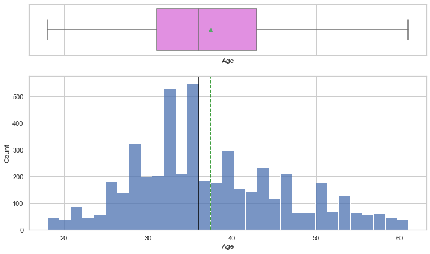

```python
# visualizing Age column
histogram_boxplot(data,'Age')
```

**Observations:**

- It's normally distributed with no outliers. we see that most customers age between 30-40 years.

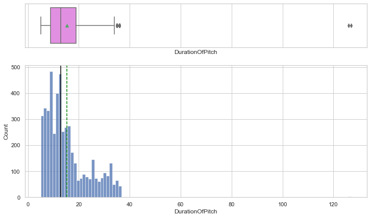

```python
# visualizing DurationOfPitch column
histogram_boxplot(data,'DurationOfPitch')
```

**Observations:**

- It's slightly right-skewed. We see that most customers pitch duration was under 20 mins.
- We also see few outliers at 40 mins and at ~120 mins.

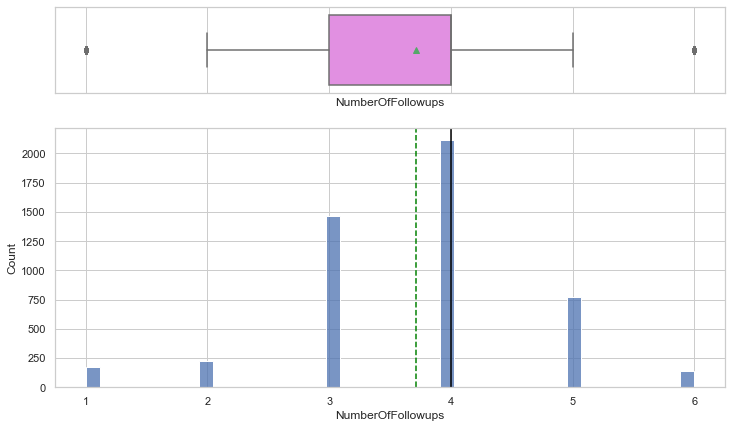

```python
# visualizing NumberOfFollowups column
histogram_boxplot(data,'NumberOfFollowups')
```

**Observations:**

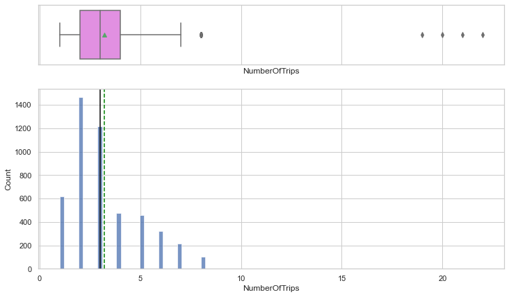

```python
# visualizing NumberOfTrips column
histogram_boxplot(data,'NumberOfTrips')
```

**Observations:**

- NumberofTrips is right-skewed and majority of the customers seem to take atleast 3 trips per year.
- We also see outliers between 10 and 20 trips.

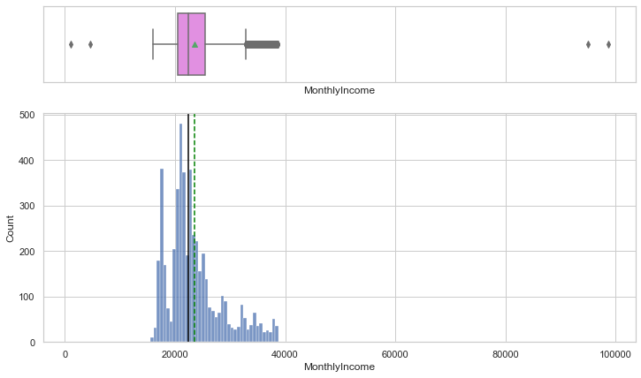

```python
# visualizing MonthlyIncome column
histogram_boxplot(data,'MonthlyIncome')
```

**Observations:**

- MonthlyIncome is also right-skewd.
- We see that the majority of customers income are between 20K dollars and 30K dollars.
- We see two outliers in both ends.
- There are some outliers after the approx 30K dollars income level.

```python
# function to create labeled barplots


def labeled_barplot(data, feature, perc=False, n=None):
    """
    Barplot with percentage at the top

    data: dataframe
    feature: dataframe column
    perc: whether to display percentages instead of count (default is False)
    n: displays the top n category levels (default is None, i.e., display all levels)
    """

    total = len(data[feature])  # length of the column
    count = data[feature].nunique()
    if n is None:
        plt.figure(figsize=(count + 1, 5))
    else:
        plt.figure(figsize=(n + 1, 5))

    plt.xticks(rotation=90, fontsize=15)
    ax = sns.countplot(
        data=data,
        x=feature,
        palette="Paired",
        order=data[feature].value_counts().index[:n].sort_values(),
    )

    for p in ax.patches:
        if perc == True:
            label = "{:.1f}%".format(
                100 * p.get_height() / total
            )  # percentage of each class of the category
        else:
            label = p.get_height()  # count of each level of the category

        x = p.get_x() + p.get_width() / 2  # width of the plot
        y = p.get_height()  # height of the plot

        ax.annotate(
            label,
            (x, y),
            ha="center",
            va="center",
            size=12,
            xytext=(0, 5),
            textcoords="offset points",
        )  # annotate the percentage

    plt.show()  # show the plot
```

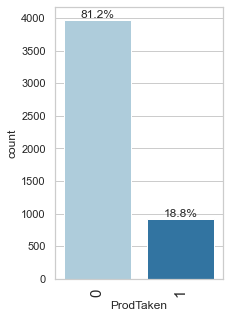

```python
#visualizing ProdTaken column
labeled_barplot(data,"ProdTaken",perc=True)
```

**Observations:**

- We see that only 18.8% of the total customers purchased any of the travel package.The plot shows heavy imbalance in the dataset

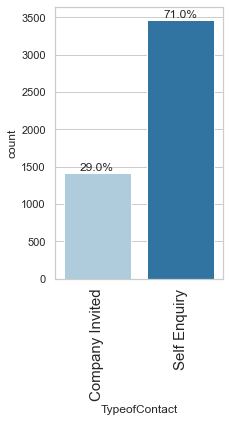

```python
#visualizing TypeofContact column
labeled_barplot(data,"TypeofContact",perc=True)
```

**Observations:**

- 71% of the customers prefered "Self Enquiry" contact method

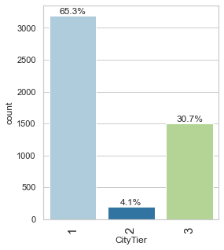

```python
#visualizing CityTier column
labeled_barplot(data,"CityTier",perc=True)
```

**Observations:**

- 65.3% of customers are from Tier 1 cities
- 30.7% of customers are from Tier 3 cities
- 4.1% of customers are from Tier 2 cities

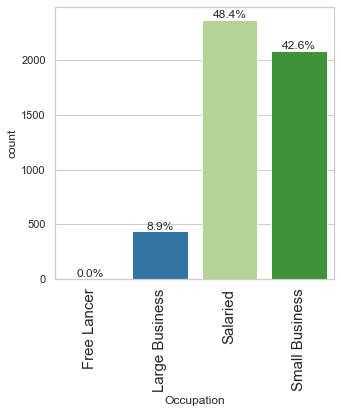

```python
#visualizing Occupation column
labeled_barplot(data,"Occupation",perc=True)
```

**Observations:**

- 48.4% of customers are Salaried
- 42.6% of customers are Small Business people
- 8.9 of customers are Large Business people
- Free Lancer customers are 0%

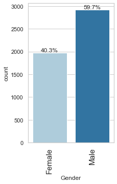

```python
#visualizing Gender column
labeled_barplot(data,"Gender",perc=True)
```

**Observations:**

- 59.7% are Male customers
- 40.3% are Female customers

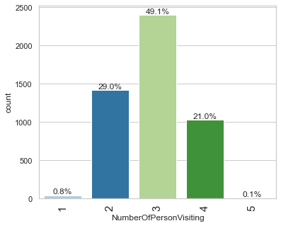

```python
#visualizing NumberOfPersonVisiting column
labeled_barplot(data,"NumberOfPersonVisiting",perc=True)
```

**Observations:**

- 49.1% of customers plan to take atleast 3 persons with them during trip
- 29% of customers plan to take atleast 2 persons with them during trip
- 21% of customers plan to take atleast 4 persons with them during trip
- Customers plan to take atleast 1 or 5 persons with them during trip are less than 1%

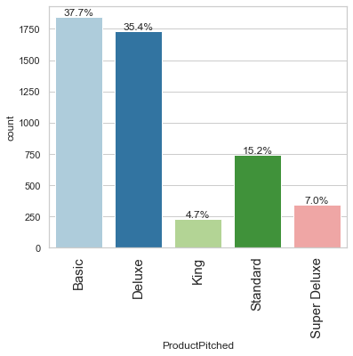

```python
#visualizing ProductPitched column
labeled_barplot(data,"ProductPitched",perc=True)
```

**Observations:**

- Basic is the most popular travel packages with 37.7%.
- The next slightly popular one is Deluxe travel package with 35.4%
- King travel package is comparatively lower than other packages with just 4.7%

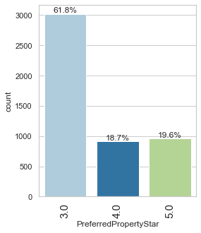

```python
#visualizing PreferedPropertyStar column
labeled_barplot(data,"PreferredPropertyStar",perc=True)
```

**Observations:**

- 61.8% of customers prefers three star hotel rating
- 18.7% of customers prefers four star hotel rating
- 19.6% of customers prefers five star hotel rating

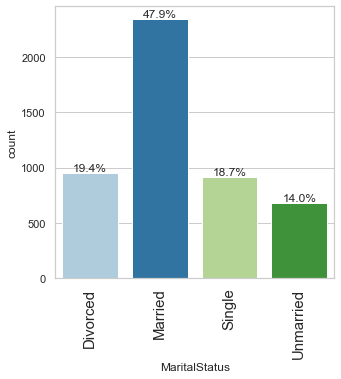

```python
#visualizing MaritalStatus column
labeled_barplot(data,"MaritalStatus",perc=True)
```

**Observations:**

- 47.9% of customers are Married customers
- 18.7% of customers are Single customers
- 19.4% of customers are Divorced customers
- 14% of customers are Unmarried customers

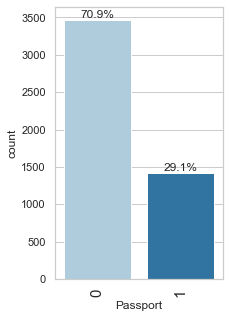

```python
#visualizing Passport column
labeled_barplot(data,"Passport",perc=True)
```

**Observations:**

- 70.9% of customers doesn't have a passport.
- Only 29.1% of customers have a passport

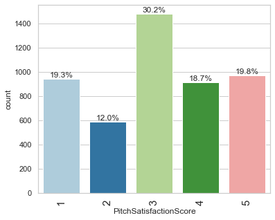

```python
#visualizing PitchSatisfactionScore column
labeled_barplot(data,"PitchSatisfactionScore",perc=True)
```

**Observations:**

- 30.2% of customers rated the Sales Pitch with a score of 3
- 18.7% of customers rated at 4
- 19.8% of customers rated a pitch score of 5
- 19.3% of customers rated the Sales pitch score at 1
- 12% of the customers rated the Sales pitch score at 2

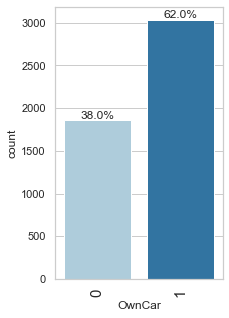

```python
#visualizing OwnCar column
labeled_barplot(data,"OwnCar",perc=True)
```

**Observations:**

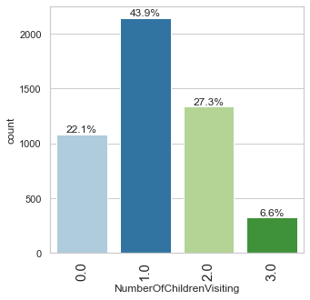

```python
#visualizing NumberOfChildrenVisiting column
labeled_barplot(data,"NumberOfChildrenVisiting",perc=True)
```

**Observations:**

- 43.9% of customers have 1 child with age less than 5 planning to take the trip with the customer
- 27.3% of customers have 2 childrens with age less than 5 planning to take the trip with the customer
- 22.1% of customers have no child with age less than 5 planning to take the trip with the customer
- 6.6% of customers have 3 childrens with age less than 5 planning to take the trip with the customer

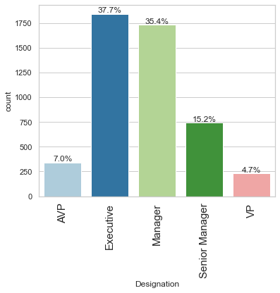

```python
#visualizing Designation column
labeled_barplot(data,"Designation",perc=True)
```

**Observations:**

- Executive designation customers are higher in the dataset with 37.7%
- 35.4% of cutomers are Managers
- 15.2% of cutomers are Senior Managers
- 7% of cutomers are AVP
- 4.7% of cutomers are VP

#### Bivariate Analysis

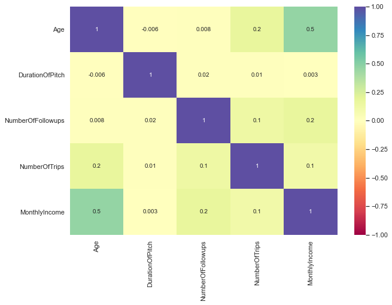

```python
plt.figure(figsize=(10,7))
sns.heatmap(data.corr(),annot=True,vmin=-1,vmax=1,fmt='.1g',cmap="Spectral")
plt.show()
```

**Observations:**

- The correlation values are low between all the variables
- MonthlyIncome and Age have the highest positive correlation
- Age and DurationofPitch have the low negative correlation

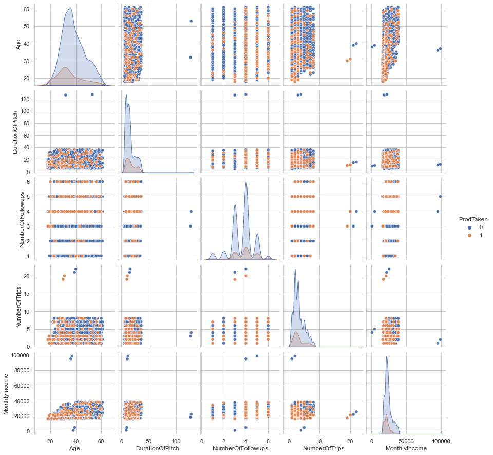

```python
sns.pairplot(data,hue='ProdTaken')
plt.show()
```

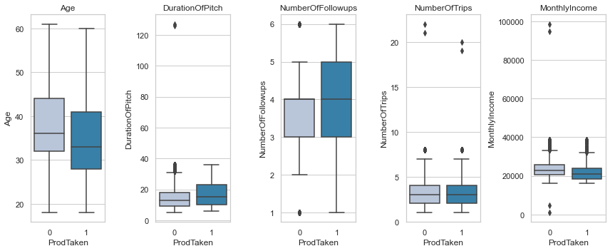

```python
cols = data[['Age', 'DurationOfPitch', 'NumberOfFollowups', 'NumberOfTrips', 'MonthlyIncome']].columns.tolist()
plt.figure(figsize=(12,5))

for i, variable in enumerate(cols):
                     plt.subplot(1,5,i+1)
                     sns.boxplot(data['ProdTaken'],data[variable],palette="PuBu")
                     plt.tight_layout()
                     plt.title(variable)
plt.show()
```

**Observations:**

- The mean Age for customers who purchased any Product is slightly less than those who didnt. We also see that Age variable doesnt have any outliers.
- The mean DurationOfPitch for both classed of ProdTaken is almost equal. We see there are many outliers in Class '0' of ProdTaken.
- Customers who purchased the packages have four followups.
- In NumberofTrips both Classes of ProdTaken is almost equal and it has outliers on both classes.
- In MonthlyIncome both Classes of ProdTaken is almost equal and it has outliers in the higher end for both ProdTaken classes and few in low end of Class '0'.

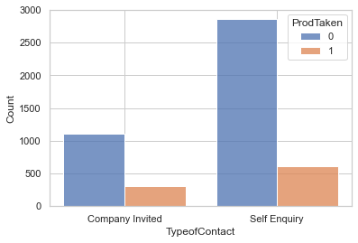

```python
sns.histplot(data=data, x="TypeofContact", hue="ProdTaken", multiple="dodge", shrink=.8)
```

**Observation:**

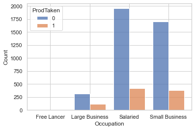

```python
sns.histplot(data=data, x="Occupation", hue="ProdTaken", multiple="dodge", shrink=.8)
```

**Observations:**

- Large Business owning customers, bought travel packages more percentage than other occupations based on counts

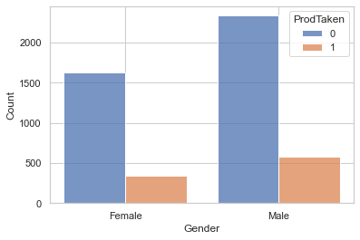

```python
sns.histplot(data=data, x="Gender", hue="ProdTaken", multiple="dodge", shrink=.8)
```

**Observations:**

- Eventhough male customers are more than female customers but buying percentage is almost equal.

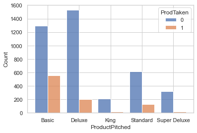

```python
sns.histplot(data=data, x="ProductPitched", hue="ProdTaken", multiple="dodge", shrink=.8)
```

**Observations:**

- The Basic Package is the most preffered, with Standard and Deluxe following up.
- Comparitively very few customers purchased King and Super Deluxe products

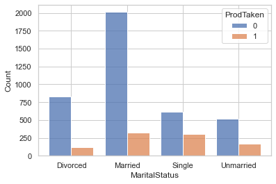

```python
sns.histplot(data=data, x="MaritalStatus", hue="ProdTaken", multiple="dodge", shrink=.8)
```

**Observations:**

- Around 30% of all Single customers have bought a product and about 25% of Unmarried customers have also purchased a product
- Almost 50% of the total customers belong to the married category, but we see that only approx 15% of them have actually purchased any product.

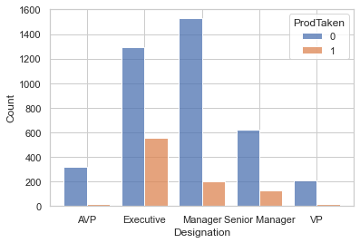

```python
sns.histplot(data=data, x="Designation", hue="ProdTaken", multiple="dodge", shrink=.8)
```

**Observations:**

- ~30% Customers with Executive Designation have purchased a product
- ~15% Senior Manager Designation customers have purchased a product.
- ~11% Manager Designation customers have purchased a product.
- Only very few customers of VP and AVP Designation have purchased a product.

### Outliers Detection and Treatment

```python
#finding the percentage of outliers using IQR
Q1 = data.quantile(0.25)
Q3 = data.quantile(0.75)

IQR = Q3 - Q1

lower=Q1-1.5*IQR
upper=Q3+1.5*IQR
```

```python
outlier_num = data.select_dtypes(include=np.number)
```

```python
((outlier_num<lower)|(outlier_num>upper)).sum()/len(data)*100
```

```
Age                  0.000000
DurationOfPitch      2.291326
NumberOfFollowups    6.382979
NumberOfTrips        2.229951
MonthlyIncome        7.671849
dtype: float64
```

**Observations:**

- MonthlyIncome and NumberofFollowups have high outliers compared to the other features.
- However, we will not be treating outliers, as we will be building Decision Tree based models and Decision Tree models are not influenced by Outliers.
- Furthermore, in real case scenario, we will encounter similar outliers and that would require the model to investigate if there is any pattern among the customers

## Model Building - Approach

- Data preparation
- Split the data into the train and test set.
- Train models on the training data.
- Try to improve the model performance using hyperparameter tuning.
- Test the performance on the test data.

### Model Evaluation Criterion

#### The model can make wrong predictions as:

- Predicting that the customer will purchase a Travel Package when they dont. - False Positive
- Predicting that the customer will not purchase a Travel Package when they do. - False Negative

#### Which case is more important?

- Target potential customers who have higher chances of buying a product.
- Predict and Identify all potential customers who will purchase the newly introduced travel package.

#### Which metric to optimize?

- We would want F1-Score to be maximized, the greater the F1-Score higher the chances of predicting both the classes correctly.

**Let's define a function to provide metric scores on the train and test set and a function to show confusion matrix so that we do not have to use the same code repetitively while evaluating models.**

```python
# defining a function to compute different metrics to check performance of a classification model built using sklearn
def model_performance_classification_sklearn(model, predictors, target):
    """
    Function to compute different metrics to check classification model performance

    model: classifier
    predictors: independent variables
    target: dependent variable
    """

    # predicting using the independent variables
    pred = model.predict(predictors)

    acc = accuracy_score(target, pred)  # to compute Accuracy
    recall = recall_score(target, pred)  # to compute Recall
    precision = precision_score(target, pred)  # to compute Precision
    f1 = f1_score(target, pred)  # to compute F1-score

    # creating a dataframe of metrics
    df_perf = pd.DataFrame(
        {
            "Accuracy": acc,
            "Recall": recall,
            "Precision": precision,
            "F1": f1,
        },
        index=[0],
    )

    return df_perf
```

```python
def confusion_matrix_sklearn(model, predictors, target):
    """
    To plot the confusion_matrix with percentages

    model: classifier
    predictors: independent variables
    target: dependent variable
    """
    y_pred = model.predict(predictors)
    cm = confusion_matrix(target, y_pred)
    labels = np.asarray(
        [
            ["{0:0.0f}".format(item) + "\n{0:.2%}".format(item / cm.flatten().sum())]
            for item in cm.flatten()
        ]
    ).reshape(2, 2)

    plt.figure(figsize=(6, 4))
    sns.heatmap(cm, annot=labels, fmt="")
    plt.ylabel("True label")
    plt.xlabel("Predicted label")
```

### Split Data

```python
X= data.drop(['ProdTaken','PitchSatisfactionScore','ProductPitched','NumberOfFollowups','DurationOfPitch'],axis=1)
y= data['ProdTaken']
```

```python
X = pd.get_dummies(X, drop_first=True)
# Splitting data into training and test set:
X_train,X_test, y_train, y_test =train_test_split(X,y, test_size=0.3, random_state=25,stratify=y)
print(X_train.shape,X_test.shape)
```

```
(3421, 28) (1467, 28)
```

**The Stratify arguments maintain the original distribution of classes in the target variable while splitting the data into train and test sets.**

```python
y.value_counts(1)
```

```
0    0.811784
1    0.188216
Name: ProdTaken, dtype: float64
```

```python
y_test.value_counts(1)
```

```
0    0.811861
1    0.188139
Name: ProdTaken, dtype: float64
```

### Decision Tree Classifier

```
Training performance:
    Accuracy  Recall  Precision   F1
0       1.0     1.0        1.0  1.0
Testing performance:
    Accuracy    Recall  Precision        F1
0  0.852079  0.601449   0.608059  0.604736
```

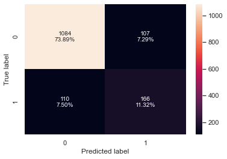

```python
#Fitting the model
d_tree = DecisionTreeClassifier(criterion='gini',class_weight={0:0.15,1:0.85},random_state=1)
d_tree.fit(X_train,y_train)

#Calculating different metrics
d_tree_model_train_perf=model_performance_classification_sklearn(d_tree,X_train,y_train)
print("Training performance:\n",d_tree_model_train_perf)
d_tree_model_test_perf=model_performance_classification_sklearn(d_tree,X_test,y_test)
print("Testing performance:\n",d_tree_model_test_perf)

#Creating confusion matrix
confusion_matrix_sklearn(d_tree,X_test,y_test)
```

**Observations:**

- The Decision Tree model seems to be overfitting in the train set.
- The F1Score for test set is 0.60

#### Hyperparameter Tuning

```python
#Choose the type of classifier.
dtree_estimator = DecisionTreeClassifier(class_weight={0:0.18,1:0.72},random_state=1)

# Grid of parameters to choose from
parameters = {'max_depth': np.arange(2,30),
              'min_samples_leaf': [1, 2, 5, 7, 10],
              'max_leaf_nodes' : [2, 3, 5, 10,15],
              'min_impurity_decrease': [0.0001,0.001,0.01,0.1]
             }

# Type of scoring used to compare parameter combinations
scorer = metrics.make_scorer(metrics.f1_score)

# Run the grid search
grid_obj = GridSearchCV(dtree_estimator, parameters, scoring=scorer,n_jobs=-1)
grid_obj = grid_obj.fit(X_train, y_train)

# Set the clf to the best combination of parameters
dtree_estimator = grid_obj.best_estimator_

# Fit the best algorithm to the data.
dtree_estimator.fit(X_train, y_train)
```

```
DecisionTreeClassifier(class_weight={0: 0.18, 1: 0.72}, max_depth=5,
                       max_leaf_nodes=15, min_impurity_decrease=0.0001,
                       random_state=1)
```

```
Training performance:
    Accuracy  Recall  Precision   F1
0       1.0     1.0        1.0  1.0
Testing performance:
    Accuracy    Recall  Precision        F1
0  0.852079  0.601449   0.608059  0.604736
```

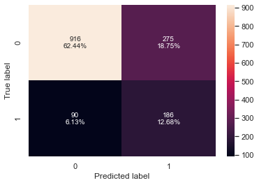

```python
#Calculating different metrics
dtree_estimator_model_train_perf=model_performance_classification_sklearn(d_tree,X_train,y_train)
print("Training performance:\n",dtree_estimator_model_train_perf)
dtree_estimator_model_test_perf=model_performance_classification_sklearn(d_tree,X_test,y_test)
print("Testing performance:\n",dtree_estimator_model_test_perf)

#Creating confusion matrix
confusion_matrix_sklearn(dtree_estimator,X_test,y_test)
```

**Observations:**

### Bagging Classifier

```
   Accuracy    Recall  Precision        F1
0  0.989769  0.947205   0.998363  0.972112
   Accuracy    Recall  Precision       F1
0  0.888889  0.536232   0.808743  0.64488
```

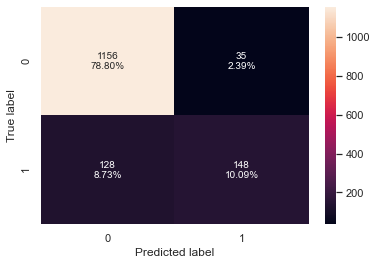

```python
#Fitting the model
bagging_classifier = BaggingClassifier(random_state=1)
bagging_classifier.fit(X_train,y_train)

#Calculating different metrics
bagging_classifier_model_train_perf=model_performance_classification_sklearn(bagging_classifier,X_train,y_train)
print(bagging_classifier_model_train_perf)
bagging_classifier_model_test_perf=model_performance_classification_sklearn(bagging_classifier,X_test,y_test)
print(bagging_classifier_model_test_perf)

#Creating confusion matrix
confusion_matrix_sklearn(bagging_classifier,X_test,y_test)
```

**Observations:**

- The Bagging classifier has a better accuracy metric and the F1 score is also higher.
- Bagging classifier is overfitting the training data.
- Let's try hyperparameter tuning and see if the model performance improves.